# Homework 1 - part 3

Francesco MONTI

2022-11-17

```r
library(stringr)
library(prettyR)
library(ggplot2)
library(tidyverse)
library(ggthemes)
library(colorRamps)
library(psych)
library(Hmisc)
library(knitr)
```

Nota bene: output will go to the console, as defined in the global options.

## 1. Import the file “BDD_VICAN.csv”

```r
data <- read.csv("BDD_VICAN.csv", sep = ";", dec = ",", encoding = "UTF-8")

names(data) = tolower(names(data)) # removing capital letters as working with them can be annoying
```

## 2. Display the first lines of the dataset. Display the lines 1; 4; 18; 103 of the dataset

|  | fc_caisse | ms_codcancer | fc_agediag_r0 | q5_sd4_r1 | q5_sd5 | q5_sd10_r2 | q5_pcs12_r1 | q5_mcs12_r1 | q5_eortc_fatigue_r1 | q5_anxiete | q5_depression | q5_jobv5.36_r1 | ms_csp_enq_3c_r1 | q5_med23.1 | id | q5_pain |
| --- | --- | --- | --- | --- | --- | --- | --- | --- | --- | --- | --- | --- | --- | --- | --- | --- |
| 1 | 1 | 1 | 51 | 1 | 1 | 3 | 36.17192 | 32.31987 | 66,666667 | 1 | 0 | 3 | 3 | 5 | 2 | 0 |
| 2 | 1 | 1 | 50 | 2 | 1 | 2 | 44.73504 | 33.16873 | 66,666667 | 2 | 0 | 1 | 1 | 5 | 3 | 0 |
| 3 | 1 | 1 | 49 | 2 | 2 | 2 | 58.32207 | 58.63898 | 22,222222 | 0 | 0 | 2 | 1 | 5 | 4 | 0 |
| 4 | 1 | 7 | 50 | 1 | 1 | 3 | 56.38174 | 51.82826 | 11,111111 | 0 | 0 | 2 | 2 | 5 | 5 | 0 |
| 5 | 1 | 10 | 26 | 1 | 1 | 3 | 61.12935 | 44.05385 | 55,555556 | 1 | 0 | 2 | 1 | 5 | 6 | 1 |
| 6 | 1 | 81 | 35 | 1 | 1 | 3 | 20.59613 | 52.33494 | 100 | 0 | 0 | 1 | 2 | 2 | 7 | 1 |

|  | fc_caisse | ms_codcancer | fc_agediag_r0 | q5_sd4_r1 | q5_sd5 | q5_sd10_r2 | q5_pcs12_r1 | q5_mcs12_r1 | q5_eortc_fatigue_r1 | q5_anxiete | q5_depression | q5_jobv5.36_r1 | ms_csp_enq_3c_r1 | q5_med23.1 | id | q5_pain |
| --- | --- | --- | --- | --- | --- | --- | --- | --- | --- | --- | --- | --- | --- | --- | --- | --- |
| 1 | 1 | 1 | 51 | 1 | 1 | 3 | 36.17192 | 32.31987 | 66,666667 | 1 | 0 | 3 | 3 | 5 | 2 | 0 |
| 4 | 1 | 7 | 50 | 1 | 1 | 3 | 56.38174 | 51.82826 | 11,111111 | 0 | 0 | 2 | 2 | 5 | 5 | 0 |
| 18 | 1 | 1 | 50 | 2 | 1 | 3 | 40.27254 | 28.48350 | 66,666667 | 2 | 1 | 1 | 2 | 3 | 19 | 1 |
| 103 | 1 | 3 | 51 | 1 | 1 | 3 | 62.53169 | 38.25137 | 22,222222 | 1 | 0 | 2 | 2 | 4 | 106 | 0 |

## 3. How many variables and observations are there?

```
## [1] 16
```

```
## [1] 3962
```

## 4. Does this file contain any missing values?

```r
sapply(data, function(x) sum(is.na(x))) # NAs by variable
```

```
##           fc_caisse        ms_codcancer       fc_agediag_r0           q5_sd4_r1
##                   0                   0                   0                   0
##              q5_sd5          q5_sd10_r2         q5_pcs12_r1         q5_mcs12_r1
##                   0                   0                   0                   0
## q5_eortc_fatigue_r1          q5_anxiete       q5_depression      q5_jobv5.36_r1
##                   0                   0                   0                   0
##    ms_csp_enq_3c_r1          q5_med23.1                  id             q5_pain
##                   0                   0                   0                   0
```

```r
sum(is.na(data)) # global NAs
```

```
## [1] 0
```

On a first impression, the dataframe looks to be free of any NAs. We’ll see later that this is not true: the variable “q5_eortc_fatigue_r1” as been incorrectly identified as “character” as missing values have been tagged as “!NULL” rather than leaving the cells empty.

As a sidenote, there is no description of “q5_eortc_fatigue_r1” in the statement of the homework

## 5. What is the nature of the variables studied?

```r
str(data)
```

```
## 'data.frame':    3962 obs. of  16 variables:
##  $ fc_caisse          : int  1 1 1 1 1 1 1 1 1 1 ...
##  $ ms_codcancer       : int  1 1 1 7 10 81 10 1 3 1 ...
##  $ fc_agediag_r0      : int  51 50 49 50 26 35 37 47 50 43 ...
##  $ q5_sd4_r1          : int  1 2 2 1 1 1 1 1 1 2 ...
##  $ q5_sd5             : int  1 1 2 1 1 1 1 2 1 2 ...
##  $ q5_sd10_r2         : int  3 2 2 3 3 3 3 3 2 2 ...
##  $ q5_pcs12_r1        : num  36.2 44.7 58.3 56.4 61.1 ...
##  $ q5_mcs12_r1        : num  32.3 33.2 58.6 51.8 44.1 ...
##  $ q5_eortc_fatigue_r1: chr  "66,666667" "66,666667" "22,222222" "11,111111" ...
##  $ q5_anxiete         : int  1 2 0 0 1 0 0 2 0 0 ...
##  $ q5_depression      : int  0 0 0 0 0 0 0 0 0 0 ...
##  $ q5_jobv5.36_r1     : int  3 1 2 2 2 1 1 2 2 1 ...
##  $ ms_csp_enq_3c_r1   : int  3 1 1 2 1 2 2 2 2 1 ...
##  $ q5_med23.1         : int  5 5 5 5 5 2 5 5 1 4 ...
##  $ id                 : int  2 3 4 5 6 7 8 9 10 11 ...
##  $ q5_pain            : int  0 0 0 0 1 1 0 0 1 0 ...
```

## 6. Some of the variables are in the wrong format, for example, a qualitative variable in “numeric” format. Based on the description of each variable (found at the beginning of this exercise), re-code the variable(s) into the correct format

```r
# replacing "," with "." is necessary for as.numeric() to work correctly
data$q5_eortc_fatigue_r1 =
  as.numeric(str_replace(data$q5_eortc_fatigue_r1, ",", "."))
sum(is.na(data$q5_eortc_fatigue_r1))  # 6 NAs introduced where cells were "!NULL"
```

```
## [1] 6
```

```r
# ----------------------------------- #
# For several variables it could be appropriate to convert them to factors but, at this stage of the analysis its rather optional.

# Health insurance
data$fc_caisse = factor(data$fc_caisse, labels = c("CNAMTS", "MSA", "RSI"))

# Pathology location
data$ms_codcancer = factor(data$ms_codcancer,
                           labels = c("Breast", "Lung", "Colon & Rectum",
                                      "Prostate", "VADS", "Bladder", "Kidney",
                                      "Thyroid", "Lymphoma", "Melanoma", "Cervix",
                                      "Uterus"))

# Marital status
data$q5_sd4_r1 = factor(data$q5_sd4_r1,
                        labels = c("Married/Partnered/Concubine",
                                   "Single/Divorced/Separated/Widowed"))

# Children yes/non
data$q5_sd5 = factor(data$q5_sd5, labels = c("Yes", "Non"))

# Level of study
data$q5_sd10_r2 <- factor(data$q5_sd10_r2,
                          labels = c("No degree", "Less than Bachelor's degree",
                                     "High school diploma or more"))

# Pain
data$q5_pain <- factor(data$q5_pain, labels = c("Yes", "Non"))

# Anxiety
data$q5_anxiete <- factor(data$q5_anxiete,
                          labels = c("No anxiety", "Questionable anxiety state",
                                     "Certain anxiety state"))

# Depression
data$q5_depression <- factor(data$q5_depression,
                             labels = c("No depression",
                                        "Questionable depression state",
                                        "Certain depression state"))

# Net salary category
data$q5_jobv5.36_r1 <- factor(data$q5_jobv5.36_r1,
                              labels = c("<1500€", ">=1500€","Not employed"))

# Social category
data$ms_csp_enq_3c_r1 <- factor(data$ms_csp_enq_3c_r1,
                                labels = c("Executives", "Managerial occupations", "Not employed"))

# Sequels
data$q5_med23.1 <- factor(data$q5_med23.1,
                          labels = c("YES and they are very important",
                                     "YES and they are important",
                                     "YES but moderate", "YES but very moderate",
                                     "NO, i have no after-effects"))
```

```r
# Associationg a label with each variable, purely for QoL
label(data$fc_caisse) <- "Health insurance"
label(data$ms_codcancer) <- "Pathology's location"
label(data$fc_agediag_r0) <- "Age"
label(data$q5_sd4_r1) <- "Marital status"
label(data$q5_sd5) <- "Children yes/non"
label(data$q5_sd10_r2) <- "Level of study"
label(data$q5_pcs12_r1) <- "Physical QoL"
label(data$q5_mcs12_r1) <- "Mental QoL"
label(data$q5_pain) <- "Pain"
label(data$q5_anxiete) <- "Anxiety"
label(data$q5_depression) <- "Depression"
label(data$q5_jobv5.36_r1) <- "Net salary"
label(data$ms_csp_enq_3c_r1) <- "Socio-professional category"
label(data$q5_med23.1) <- "Sequels"
label(data$q5_eortc_fatigue_r1) <- "EORTC fatigue scale"
```

## 7. Definition of clinically significant fatigue score: score >= 40 on the fatigue scale included in the survey, the threshold at which a fatigue condition was shown to be clinically significant. Create a categorical variable based on this definition.

```r
data$q5_eortc_fatigue_r1_fac =
  cut(data$q5_eortc_fatigue_r1,
      breaks = c(0,40,100),
      labels = c("Not Clinically significant", "Clinically significant"),
      include.lowest = T)

label(data$q5_eortc_fatigue_r1_fac) <- "EORTC fatigue scale"
```

## 8. Group the modalities of the variable sequelae into 3 modalities. This new variable, named “Q5_med23.1_rec” will be considered in the following analyses instead of “Q5_med23.1”.

```r
data$q5_med23.1_rec = factor(data$q5_med23.1,
                             labels = c("Important sequelae","Important sequelae",
                                        "Moderate sequelae", "Moderate sequelae",
                                        "No sequelae"))

label(data$q5_med23.1_rec) = "Sequels"
```

## 9. Display the frequency table for this new variable.

```r
a = table(data$q5_med23.1_rec)
b = paste(round(prop.table(table(data$q5_med23.1_rec))*100,2),"%")

print(rbind(a,b))
```

```
##   Important sequelae Moderate sequelae No sequelae
## a "907"              "1652"            "1403"
## b "22.89 %"          "41.7 %"          "35.41 %"
```

## 10. Concerning age: What is the average age of our study population, then that of breast cancer.

```r
whole_pop = data$fc_agediag_r0
breast_pop = data$fc_agediag_r0[which(data$ms_codcancer=="Breast")]

mean(whole_pop) # Mean age of our population
```

```
## [1] 54.71858
```

```r
mean(breast_pop, na.rm=T) # mean age for breast cancer subpopulation.
```

```
## [1] 50.34656
```

### Determine the 95% confidence intervals (CI) for each of the calculated means.

```r
t.test(whole_pop)$"conf.int" # T confidence intervals for the whole population
```

```
## [1] 54.33283 55.10433
## attr(,"conf.level")
## [1] 0.95
```

```r
t.test(breast_pop)$"conf.int" # T confidence interval for the breast cancer subpopulation
```

```
## [1] 49.72758 50.96554
## attr(,"conf.level")
## [1] 0.95
```

### Calculate the variance, standard deviation of the sample, then that of breast cancer.

```r
prettyR::describe(whole_pop,num.desc=c("var","sd"), xname="the age variable for the whole population", horizontal=FALSE)
```

```
## Description of the age variable for the whole population
```

```
##
##  Numeric
##      var    sd
## x 153.38 12.38
```

```r
prettyR::describe(breast_pop,num.desc=c("var","sd"), xname="the age variable for the breast cancer population", horizontal=FALSE)
```

```
## Description of the age variable for the breast cancer population
```

```
##
##  Numeric
##      var    sd
## x 112.86 10.62
```

## 11. Draw a graph that will represent the distribution of age by location of the pathology. Choose the most appropriate graph. Export the graph in a pdf format.

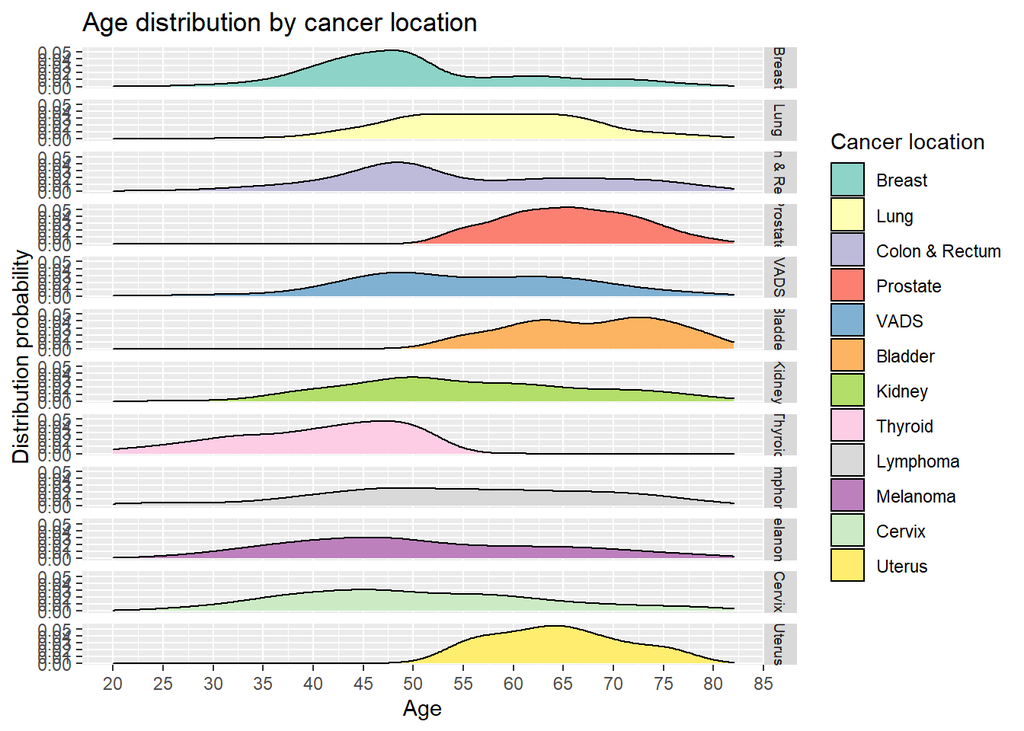

```r
# Solution 1
ggplot(data = data,
       aes(x=fc_agediag_r0, group = ms_codcancer, fill = ms_codcancer)) +
    geom_density()+
    scale_fill_brewer(palette="Set3")+
    scale_y_continuous(breaks = seq(0,0.1, 0.01), minor_breaks = seq(0, 0.005, 0.01))+
    scale_x_continuous(breaks = seq(0,100, 5))+
    labs(x = "Age",
         y = "Distribution probability",
         title = "Age distribution by cancer location",
         fill = "Cancer location")+
    facet_grid(vars(ms_codcancer))+
    theme(strip.text.y = element_text(size = 7))
```

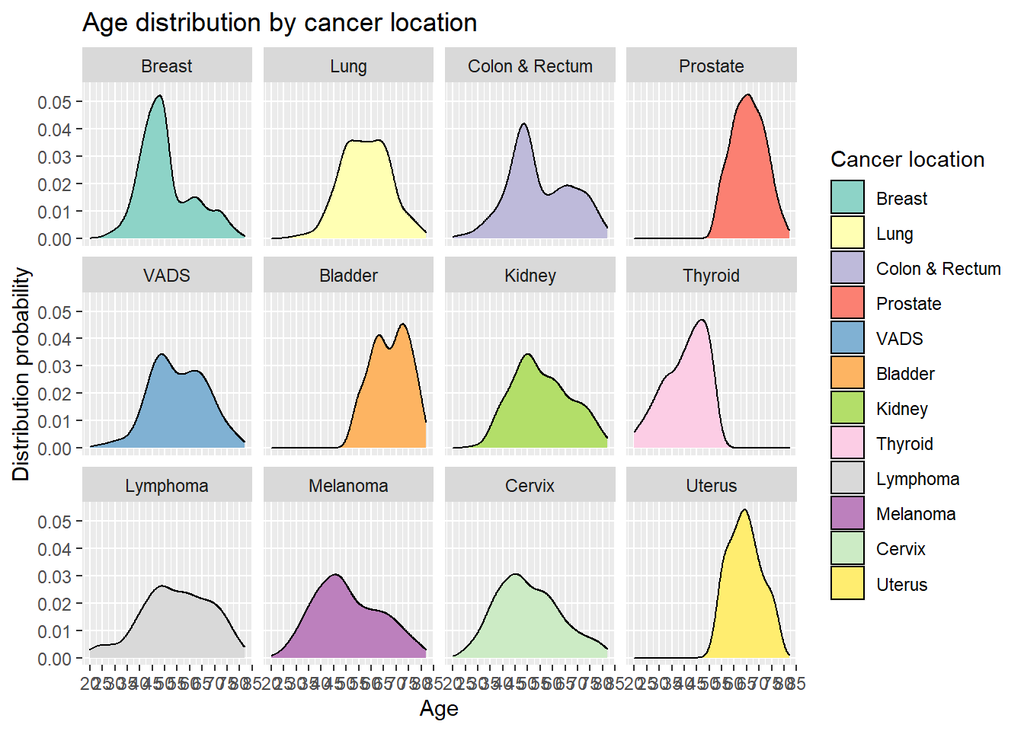

```r
ggsave("Solution 1.pdf", plot = last_plot(), device = "pdf", dpi = 300, width = 20, height = 35, units = "cm")

# Solution 2
ggplot(data = data,
       aes(x=fc_agediag_r0, group = ms_codcancer, fill = ms_codcancer)) +
  geom_density()+
  scale_fill_brewer(palette="Set3")+
  scale_y_continuous(breaks = seq(0,0.1, 0.01), minor_breaks = seq(0, 0.005, 0.01))+
  scale_x_continuous(breaks = seq(0,100, 5))+
  labs(x = "Age",
       y = "Distribution probability",
       title = "Age distribution by cancer location",
       fill = "Cancer location")+
    facet_wrap(vars(ms_codcancer))
```

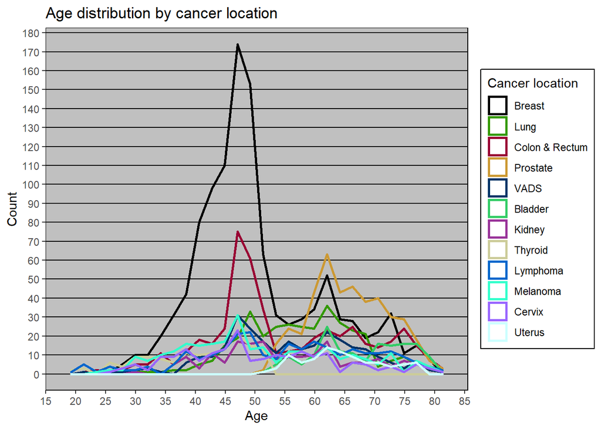

```r
ggsave("Solution 2.pdf", plot = last_plot(), device = "pdf", dpi = 300, width = 40, height = 30, units = "cm")

# Solution 3
ggplot(data = data,
       aes(x=fc_agediag_r0, group = ms_codcancer, colour = ms_codcancer)) +
    geom_density(stat = "bin", size = 1)+
    scale_color_manual(values = primary.colors(n=12, step = 6))+
    scale_x_continuous(breaks = seq(0,100, 5))+
    scale_y_continuous(breaks = seq(0,1000, 10))+
    labs(x = "Age",
         y = "Count",
         title = "Age distribution by cancer location",
         colour = "Cancer location")+ theme_excel()
```

```r
ggsave("Solution 3.pdf", plot = last_plot(), device = "pdf", dpi = 300, width = 25, height = 20, units = "cm")
```

## 12. Determine the factors associated with physical and then mental quality of life, including variables with a p-value < 0.2. Which model will you use? How will you proceed? Interpret the final result.

```r
# Listing the explicative variables
explicative_variables = c("fc_caisse", "ms_codcancer","fc_agediag_r0","q5_sd4_r1","q5_sd5","q5_sd10_r2","q5_eortc_fatigue_r1_fac", "q5_anxiete","q5_depression","q5_jobv5.36_r1","ms_csp_enq_3c_r1", "q5_med23.1_rec","q5_pain")

# Printing the list of explicative variables, with their labels, that are gonna be used in the model
kable(label(data[explicative_variables]))
```

|  | x |
| --- | --- |
| fc_caisse | Health insurance |
| ms_codcancer | Pathology’s location |
| fc_agediag_r0 | Age |
| q5_sd4_r1 | Marital status |
| q5_sd5 | Children yes/non |
| q5_sd10_r2 | Level of study |
| q5_eortc_fatigue_r1_fac | EORTC fatigue scale |
| q5_anxiete | Anxiety |
| q5_depression | Depression |
| q5_jobv5.36_r1 | Net salary |
| ms_csp_enq_3c_r1 | Socio-professional category |
| q5_med23.1_rec | Sequels |
| q5_pain | Pain |

```r
# Recoding the reference for qualitative variables
# List of factors to be recoded to make sure we correctly interpret the results
subset(sapply(data,is.factor), sapply(data,is.factor)==1)
```

```
##               fc_caisse            ms_codcancer               q5_sd4_r1
##                    TRUE                    TRUE                    TRUE
##                  q5_sd5              q5_sd10_r2              q5_anxiete
##                    TRUE                    TRUE                    TRUE
##           q5_depression          q5_jobv5.36_r1        ms_csp_enq_3c_r1
##                    TRUE                    TRUE                    TRUE
##              q5_med23.1                 q5_pain q5_eortc_fatigue_r1_fac
##                    TRUE                    TRUE                    TRUE
##          q5_med23.1_rec
##                    TRUE
```

```r
data$fc_caisse <- relevel(data$fc_caisse, ref = "CNAMTS")
data$ms_codcancer <- relevel(data$ms_codcancer, ref = "Breast")
data$q5_sd4_r1 <- relevel(data$q5_sd4_r1, ref = "Married/Partnered/Concubine")
data$q5_sd5 <- relevel(data$q5_sd5, ref = "Non")
data$q5_sd10_r2 <- relevel(data$q5_sd10_r2, ref = "No degree")
data$q5_anxiete <- relevel(data$q5_anxiete, ref = "No anxiety")
data$q5_jobv5.36_r1 <- relevel(data$q5_jobv5.36_r1, ref = "Not employed")
data$ms_csp_enq_3c_r1 <- relevel(data$ms_csp_enq_3c_r1, ref = "Not employed")
data$q5_med23.1_rec <- relevel(data$q5_med23.1_rec, ref = "No sequelae")
data$q5_pain <- relevel(data$q5_pain, ref = "Non")
data$q5_depression <- relevel(data$q5_depression, ref = "No depression")
data$q5_eortc_fatigue_r1_fac <- relevel(data$q5_eortc_fatigue_r1_fac, ref = "Not Clinically significant")

# Checking if any of the factor levels has a low effective
data %>% select(where(is.factor)) %>% apply(2,table)
```

```
## $fc_caisse
##
## CNAMTS    MSA    RSI
##   3005    531    426
##
## $ms_codcancer
##
##        Bladder         Breast         Cervix Colon & Rectum         Kidney
##            158           1134            190            492            182
##           Lung       Lymphoma       Melanoma       Prostate        Thyroid
##            343            266            273            423            141
##         Uterus           VADS
##             90            270
##
## $q5_sd4_r1
##
##       Married/Partnered/Concubine Single/Divorced/Separated/Widowed
##                              2870                              1092
##
## $q5_sd5
##
##  Non  Yes
##  435 3527
##
## $q5_sd10_r2
##
## High school diploma or more Less than Bachelor's degree
##                        1910                        1793
##                   No degree
##                         259
##
## $q5_anxiete
##
##      Certain anxiety state                 No anxiety
##                        901                       2128
## Questionable anxiety state
##                        933
##
## $q5_depression
##
```

[output cut: 23 more lines]

```
##
## $q5_pain
##
##  Non  Yes
## 1019 2943
##
## $q5_eortc_fatigue_r1_fac
##
##     Clinically significant Not Clinically significant
##                       1938                       2018
##
## $q5_med23.1_rec
##
## Important sequelae  Moderate sequelae        No sequelae
##                907               1652               1403
```

```r
# Physical QoL
mod1 <- lm(data = data, q5_pcs12_r1 ~ fc_caisse + ms_codcancer + fc_agediag_r0 + q5_sd4_r1 + q5_sd5 + q5_sd10_r2 + q5_eortc_fatigue_r1_fac + q5_anxiete + q5_depression + q5_jobv5.36_r1 + q5_med23.1_rec + q5_pain + q5_mcs12_r1)

# Mental QoL
mod2 <- lm(data = data, q5_mcs12_r1 ~ fc_caisse + ms_codcancer + fc_agediag_r0 + q5_sd4_r1 + q5_sd5 + q5_sd10_r2 + q5_eortc_fatigue_r1_fac + q5_anxiete + q5_depression + q5_jobv5.36_r1 + q5_med23.1_rec + q5_pain + q5_pcs12_r1)

# Factors associated to physical QoL score
subset(summary(mod1)$coefficients,
       summary(mod1)$coefficients[, 4] < 0.2) %>% # filter for p-value<0.2
  data.frame() %>%
  arrange(Estimate) %>% # ordering according to the column Estimate
  kable(caption = "Factors associated to physical QoL score",
        col.names = c("Estimate", "Std error", "t-value", "P-value"))
```

Factors associated to physical QoL score

|  | Estimate | Std error | t-value | P-value |
| --- | --- | --- | --- | --- |
| q5_eortc_fatigue_r1_facClinically significant | -7.9531291 | 0.2898231 | -27.441319 | 0.0000000 |
| q5_med23.1_recImportant sequelae | -5.8034204 | 0.3659216 | -15.859738 | 0.0000000 |
| q5_depressionCertain depression state | -5.6313473 | 0.5287921 | -10.649454 | 0.0000000 |
| q5_depressionQuestionable depression state | -3.0918624 | 0.4234795 | -7.301091 | 0.0000000 |
| ms_codcancerLung | -1.9713987 | 0.4908194 | -4.016546 | 0.0000602 |
| q5_med23.1_recModerate sequelae | -1.8759536 | 0.2915953 | -6.433416 | 0.0000000 |
| ms_codcancerKidney | -0.9102051 | 0.6173612 | -1.474348 | 0.1404681 |
| q5_mcs12_r1 | -0.1461533 | 0.0154223 | -9.476765 | 0.0000000 |
| fc_agediag_r0 | -0.0841834 | 0.0144784 | -5.814419 | 0.0000000 |
| ms_codcancerMelanoma | 0.7944655 | 0.5243222 | 1.515224 | 0.1297962 |
| ms_codcancerColon & Rectum | 0.8968529 | 0.4200487 | 2.135117 | 0.0328132 |
| q5_jobv5.36_r1<1500€ | 0.9992067 | 0.3976964 | 2.512486 | 0.0120282 |
| ms_codcancerLymphoma | 1.0189050 | 0.5261088 | 1.936681 | 0.0528560 |
| ms_codcancerVADS | 1.1165635 | 0.5317606 | 2.099749 | 0.0358146 |
| ms_codcancerBladder | 1.2017636 | 0.6813797 | 1.763721 | 0.0778568 |
| q5_sd10_r2Less than Bachelor’s degree | 1.5646119 | 0.5083774 | 3.077658 | 0.0021007 |
| ms_codcancerProstate | 2.6837647 | 0.4796683 | 5.595042 | 0.0000000 |
| q5_jobv5.36_r1>=1500€ | 2.7811554 | 0.3908075 | 7.116432 | 0.0000000 |
| q5_sd10_r2High school diploma or more | 3.1894703 | 0.5231439 | 6.096736 | 0.0000000 |
| q5_painYes | 3.6691743 | 0.3014531 | 12.171625 | 0.0000000 |
| (Intercept) | 56.5543576 | 1.3691412 | 41.306448 | 0.0000000 |

```r
# Factors associated to mental QoL score
subset(
  summary(mod2)$coefficients,
  summary(mod2)$coefficients[, 4] < 0.2) %>% # filter for p-value<0.2
  data.frame() %>%
  arrange(Estimate) %>% # ordering according to the column Estimate
  kable(caption = "Factors associated to mental QoL score",
        col.names = c("Estimate", "Std error", "t-value", "P-value"))
```

Factors associated to mental QoL score

|  | Estimate | Std error | t-value | P-value |
| --- | --- | --- | --- | --- |
| q5_depressionCertain depression state | -8.9875323 | 0.5297493 | -16.965632 | 0.0000000 |
| q5_anxieteCertain anxiety state | -7.8352006 | 0.3484953 | -22.482947 | 0.0000000 |
| q5_eortc_fatigue_r1_facClinically significant | -6.6832389 | 0.3056678 | -21.864388 | 0.0000000 |
| q5_depressionQuestionable depression state | -5.3710770 | 0.4277356 | -12.557004 | 0.0000000 |
| q5_anxieteQuestionable anxiety state | -4.0793367 | 0.3158164 | -12.916797 | 0.0000000 |
| q5_med23.1_recImportant sequelae | -2.5384246 | 0.3840921 | -6.608896 | 0.0000000 |
| q5_med23.1_recModerate sequelae | -1.0668308 | 0.2994483 | -3.562654 | 0.0003715 |
| q5_sd4_r1Single/Divorced/Separated/Widowed | -0.9770976 | 0.2884332 | -3.387604 | 0.0007120 |
| q5_sd5Yes | -0.7123245 | 0.4097851 | -1.738288 | 0.0822385 |
| q5_pcs12_r1 | -0.1530166 | 0.0161465 | -9.476765 | 0.0000000 |
| fc_agediag_r0 | 0.0268096 | 0.0148719 | 1.802697 | 0.0715124 |
| q5_jobv5.36_r1>=1500€ | 0.6593942 | 0.4023117 | 1.639013 | 0.1012906 |
| ms_codcancerProstate | 0.6675365 | 0.4926395 | 1.355020 | 0.1754890 |
| ms_codcancerVADS | 0.9938414 | 0.5441775 | 1.826319 | 0.0678782 |
| ms_codcancerLung | 1.4327711 | 0.5027227 | 2.850023 | 0.0043944 |
| q5_painYes | 1.5061492 | 0.3132951 | 4.807446 | 0.0000016 |
| (Intercept) | 58.3405934 | 1.3959080 | 41.794010 | 0.0000000 |

#### How to interpret the linear regression model

Printed tables have already been filter to exclude results with a p-value >= 0.2 criteria.

Nota bene: these are *associations*, not implying causality.

**Categorical variables**: under the column “Estimate”, the table shows the average difference between a given modality and the reference modality for the same factor variable, as defined in the code chunk “*recoding reference mod for factor variables*”.  
For example, patients in a “*Certain depression state*” score, on average, 5.63 points lower for Physical QoL compared to “*non-depressed*” patients.  
According to the same logic, someone with a monthly salary over 1500€ scores on average 2.78 points higher compaired to un unemployed patient.  
The same logic applies all others categorical variables and modalities.

**Quantitative variables**: two are the numeric variables taken into account by the model, patient’s age and “the other” QoL score.  
In a plot where x=“Age” and Y=QoL score, *Estimate* is the coefficient that ties the two variables.  
For example, for every additional year of age at diagnosis, physical QoL score lowers, on average, by 0.084 .

**Key messages:**

Nota bene: the huge population allow us to have great statistical power, lots of associations come out as statistically relevant but the magnitude of the effect is very small and frankly irrelevant on a scale that goes from 0 to 100 (or so it seems, we’ve no additional information on scale boundaries).

Patients with *sequels* and *clinically significant fatigue* are also associated with scores notably lower.

  no meaningful hypothesis/explanation can be formulated.

## 13. Export the new database in “.csv” format.